```python
import numpy as np
from numpy.fft import fft, ifft
from scipy.io.wavfile import read
from scipy.signal import sawtooth, square, butter, filtfilt
from scipy.linalg import circulant
import matplotlib.pyplot as plt
from IPython.display import Audio
fs = 44100
```

# Week 4 Activity: Delay, Filters, Reverb

Complete this activity as part of your participation grade. Pending length of the lecture, you will have time in class to work. Everything you need to complete this activity can be found in this week's (or a previous week's) lecture code. For this activity, you may want to consult your Audio Tech I notes (or the Computer Music Tutorial)

## Delay

1. Create a function that will modify a passed signal by adding a delay of $m$ milliseconds to the signal.
2. Modify the function such that you can optionally scale the amplitude of the delayed signal
3. Modify the function so that the user can specify the number of delays to add to the original signal (and optionally, scale each subsequent delay amplitude by a factor of $1/n$

```python
def delay(signal, delayTime, numDelays=1, gain=0.5, fs=fs):
    """
    delayTime (ms)
    Description here
    """
    padSamps = int(fs*delayTime/1000)
    delayed = np.pad(signal, (0,padSamps*numDelays)).astype(float)
    delayed += sum([(gain**i)*np.roll(delayed, padSamps*i) for i in range(1, numDelays+1)])
    # print(padSamps)
    # for i in range(numDelays):
    #     print(delayed)
    #     delayed += gain*np.roll(signal, padSamps)
    return delayed

a = np.arange(10)
delay(a, .5, 2)
```

```
array([0.  , 1.  , 2.  , 3.  , 4.  , 5.  , 6.  , 7.  , 8.  , 9.  , 0.  ,
       0.  , 0.  , 0.  , 0.  , 0.  , 0.  , 0.  , 0.  , 0.  , 0.  , 0.  ,
       0.  , 0.5 , 1.  , 1.5 , 2.  , 2.5 , 3.  , 3.5 , 4.  , 4.5 , 0.  ,
       0.  , 0.  , 0.  , 0.  , 0.  , 0.  , 0.  , 0.  , 0.  , 0.  , 0.  ,
       0.  , 0.25, 0.5 , 0.75, 1.  , 1.25, 1.5 , 1.75, 2.  , 2.25])
```

```python
fs_miles, miles = read("../audio/MilesDavis_track2.wav")
Audio(delay(miles, 500, 4, 0.25, fs_miles), rate=fs_miles)
```

[interactive chart not shown]

## Filters

1. Create a function that will apply an feedforward comb filter by computing the delay length based off a given resonant frequency in Hz.
2. Create a function that will apply an feedback comb filter by computing the delay length based off a given resonant frequency in Hz.
4. Use your comb filter functions on a wave from the audio folder. Try applying different resonant frequencies and delay lengths. How are the filter results different?
3. Create a function that will apply a butterworth filter to a signal with filter type options 'highpass', 'lowpass', 'bandpass', and 'bandstop'.

```python
def comb(x, resonant_freq, gain=0.9, feedback=True, fs=fs):
    """
    x (np array): signal input
    resonant_freq (Hz): First resonant freq of the comb
    feedback (bool): Toggle IIR or FIR
    """
    delay_samps = int(fs * 1/resonant_freq)
    delay_from = (lambda d: x[d], lambda d: y[d])[feedback]
    # I think there is a flaw here, b/c the
    # filtered signal would theoretically be longer
    # than the original, yet we cut it off
    y = np.copy(x)
    for n in range(x.size):
        if (d := n - delay_samps) >= 0:
            y[n] += gain*delay_from(d)
    return y
```

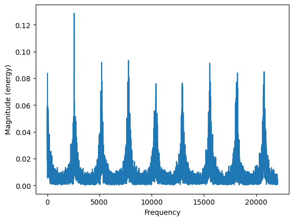

```python
x = np.random.normal(0,1,int(fs/2))
plt.magnitude_spectrum(comb(x, 2500, 0.8), Fs=fs)
```

[interactive chart not shown]

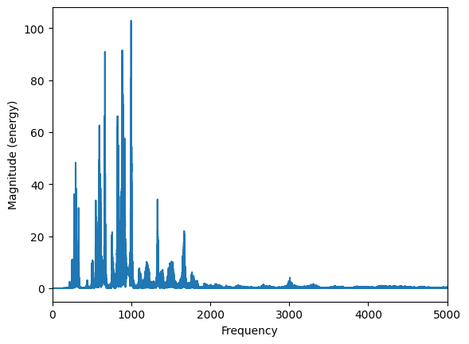

```python
#Testing
fs_scale, scale = read("../audio/femaleSingingScale.wav")
plt.magnitude_spectrum(scale, Fs=fs_scale)
plt.xlim((0, 5000))
Audio(scale, rate=fs_scale)
```

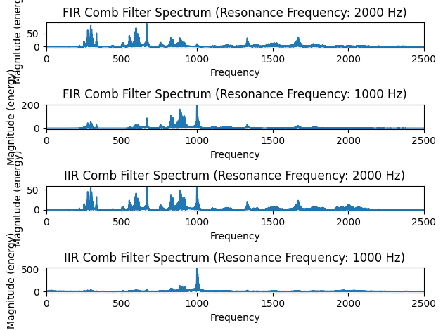

```python
plotData = [
    # resonance_freq, feedback
    (2000, False),
    (1000, False),
    (2000, True),
    (1000, True),
]
entries = len(plotData)
for i, (freq, feedback) in enumerate(plotData):
    plt.subplot(entries, 1, i+1)
    filter_type = ("FIR", "IIR")[feedback]
    title = f"{filter_type} Comb Filter Spectrum (Resonance Frequency: {freq} Hz)"
    plt.title(title)
    comb_i = comb(scale, freq, feedback=feedback, fs=fs_scale)
    plt.magnitude_spectrum(comb_i, Fs=fs_scale)
    plt.xlim((0, 2500))
plt.tight_layout()
```

```python
comb_scale = comb(scale, 2000, feedback=False, fs=fs_scale)
Audio(comb_scale, rate=fs_scale)
```

[interactive chart not shown]

```
lowpass
highpass
bandpass
bandstop
```

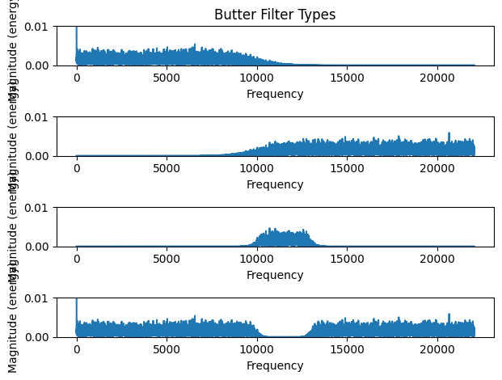

```python
# 3. Create a function that will apply a butterworth filter to a signal with
# filter type options 'highpass', 'lowpass', 'bandpass', and 'bandstop'.
def applyButter(x, cutoff, order=1, btype='lowpass', fs=fs):
    """
    x (np array): input signal
    cutoff: cutoff freq
        (scalar for highpass/lowpass, length 2 for bandpass/bandstop)
    btype (str): filter type 'highpass', 'lowpass', 'bandpass', and 'bandstop'
    out (np array): filtered signal
    """
    print(btype)
    b, a = butter(order, cutoff, btype=btype, fs=fs)
    return filtfilt(b, a, x)

# ------
noise = np.random.uniform(0,1,fs)
plt.subplot(4,1,1)
plt.title("Butter Filter Types")
y = applyButter(noise, 10000, 5, btype='lowpass')
plt.magnitude_spectrum(y, Fs=fs)
plt.ylim((0, 0.01))

plt.subplot(4,1,2)
y = applyButter(noise, 10000, 5, btype='highpass')
plt.magnitude_spectrum(y, Fs=fs)
plt.ylim((0, 0.01))

plt.subplot(4,1,3)
y = applyButter(noise, (10000, 13000), 5, btype='bandpass')
plt.magnitude_spectrum(y, Fs=fs)
plt.ylim((0, 0.01))

plt.subplot(4,1,4)
y = applyButter(noise, (10000, 13000), 5, btype='bandstop')
plt.magnitude_spectrum(y, Fs=fs)
plt.ylim((0, 0.01))
plt.tight_layout()
```

## Reverb/Convolution

1. Create a function that will apply a simple moving average filter by convolving the filter kernel and an incoming signal.
2. Apply your filter to a noise signal. What is the effect? What happens if you increase or decrease the kernel size?
3. Create a function that applies convolution reverb to an input signal given an impulse response (this can be default loaded from the audio files). Use np.convolve to create this function.
4. Create another function that applies convolution reverb to an input signal given an impulse response, but this time do not use np.convolve. You should write the convolution from scratch.

   Challenge yourself to create the most efficient function and time your implementation against np.convolve. While developing and testing your function, do not use real audio files. Start with short signals (e.g., impulses, noise, or short sinusoids). Using long signals with loop-based implementations will result in extremely slow run times.

   **Hint:** in a similar manner to how you may have designed your delay function, recall the functions `numpy.zeros` and `numpy.roll` along with how to manipulate multidimensional numpy arrays (e.g., scalar product, summing columns with `vstack`, etc.) If you plan to try `numpy.roll` DO NOT use it in a loop for convolution with a real audio file! (You'll kill your memory), instead consider the `map` function. You may also want to check out the following function which is similar to numpy.roll but more efficient for this task: `scipy.linalg.circulant`.

   You may wish to visit [here](https://numpy.org/doc/stable/user/basics.broadcasting.html) for review of broadcasting (i.e., form some calculation across index value I and column value C) in numpy

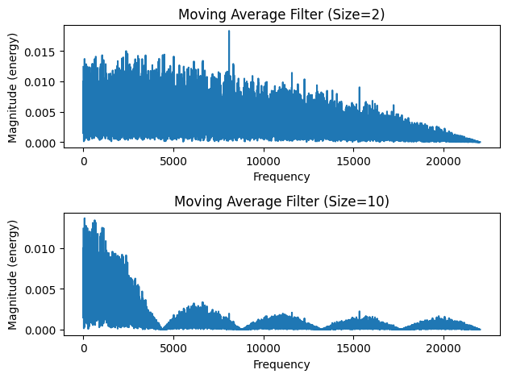

```python
# 1. Moving Average Filter
def average_filter(x, size, fs=fs):
    """
    x (np array): input signal
    size (int): size of the kernel
    out: (np array) filtered signal (sinc function)
    """
    kernel = np.ones(size) / size
    return np.convolve(x,kernel)


# 2. Testing Moving Average Filter
# Result: It seems the number of bumps in the sinc function is equal to
# size/2. That probably roughly describes the frequency of the function
noise = np.random.normal(0,1,fs)
plt.subplot(2,1,1)
plt.magnitude_spectrum(average_filter(noise, 2), Fs=fs)
plt.title("Moving Average Filter (Size=2)")

plt.subplot(2,1,2)
plt.magnitude_spectrum(average_filter(noise, 10), Fs=fs)
plt.title("Moving Average Filter (Size=10)")

plt.tight_layout()
```

```python
# Convolution setup

def to_mono_float(data):
    """Convert data to single channel and normalized to 0-1 (float)"""
    data_c = np.copy(data)
    if len(data_c.shape) > 1:
        data_c = data_c[:,0]
    # divides by max int to keep scaling same
    return data_c.astype(np.float32, order='C')/32768.0

fs_impulse, impulse = read("../audio/IR_medium.wav")
fs_hello, hello = read("../audio/hellos.wav")

impulse = to_mono_float(impulse)
hello = to_mono_float(hello)
print(hello.size)
Audio(hello, rate=fs_hello)
```

```
51200
```

[interactive chart not shown]

```python
# 3. Convolution Reverb
# 3. Create a function that applies convolution reverb to an input
# signal given an impulse response (this can be default loaded from the audio files).
# Use np.convolve to create this function.


# print(fs_impulse, impulse)
def reverb(x, ir=impulse):
    """
    x (np array): input signal
    ir (np array) impulse response of reverb
    out: (np array) signal with reverb (convolution)
    """
    return np.convolve(x, impulse)

Audio(reverb(hello), rate=fs_hello)
```

[interactive chart not shown]

We need to multiply signal g by signal f over time and add at each time position. This looks like sliding signal g across signal f. The result is the output of the convolution at that time position.

[output not shown]

```python
# Custom Convolution

a = np.array([2,4,3,6])
b = np.array([1,5,2,3,4])

def convolve_algo_1(a, b):
    """
    Matrix multiplication with circulant matrix
    reshaped back to row vector
    """
    a = np.pad(a, (0, (size_b := b.size)-1))
    return (circulant(a)[:,:size_b] @ b[:,np.newaxis]).reshape(-1,)


def convolve_algo_2(a,b):
    """"
    Algo 1 looks good line-wise, but it uses a ton of space for the circulant matrix
    and matrix multiplication.
    """
    i,n,j,m = 0, a.size, 0, b.size
    result = np.zeros(n+m-1)
    while i < n or j < m-1:
        # print(f"i:{i} j:{j}")
        k, l, i_r = i, j, i+j
        while(k < n and l >= 0):
            # print(f"k:{k},l:{l}")
            result[i_r] += a[k]*b[l]
            k, l = k+1, l-1

        if j < m-1: j += 1
        else: i += 1
    return result

def convolve_algo_3(a,b):
    """
    Now I see. After a lot of research, it ultimately comes back to the fast FFT.
    Convolution in time is multiplication in the frequency domain.
    Since FFT can get us to the frequency domain in O(nlogn) time, then
    converting both signals to frequency domain, multiplying, and
    converting the result back is still O(nlogn), which is better
    than the O(n^2) of matrix multiplication. Fast FFT is quite
    useful.
    Pad to avoid something about continued convolution.
    Need to fully understand the math of FT to get this.
    """
    a, b = np.pad(a, (0, b.size-1)), np.pad(b, (0, a.size-1))

    return np.real(ifft(fft(a)*fft(b)))


print(f"algo 1:\n{convolve_algo_1(a,b)}")
print(f"algo 2:\n{convolve_algo_2(a,b)}")
print(f"algo 3:\n{convolve_algo_3(a,b)}")
print(f"expected:\n{np.convolve(a,b)}")
```

```
algo 1:
[ 2 14 27 35 56 37 30 24]
algo 2:
[ 2. 14. 27. 35. 56. 37. 30. 24.]
algo 3:
[ 2. 14. 27. 35. 56. 37. 30. 24.]
expected:
[ 2 14 27 35 56 37 30 24]
```

```python
# a = np.arange(10)
# a = np.arange(100)
a = np.arange(1000)
# a = np.arange(10000)
# a = np.arange(100000)
b = a
```

```python
%%timeit
np.convolve(a,b)
```

```
836 µs ± 303 µs per loop (mean ± std. dev. of 7 runs, 1,000 loops each)
```

```python
%%timeit
convolve_algo_1(a,b)
```

```
10.8 ms ± 2.11 ms per loop (mean ± std. dev. of 7 runs, 100 loops each)
```

```python
%%timeit
convolve_algo_2(a,b)
```

```
836 ms ± 124 ms per loop (mean ± std. dev. of 7 runs, 1 loop each)
```

```python
%%timeit
convolve_algo_3(a,b)
```

```
840 µs ± 135 µs per loop (mean ± std. dev. of 7 runs, 100 loops each)
```

### Execution Time

| a,b size | np.convolve | algo 1 (mat mul) | algo 2 (loops) | algo 3 (fft) |
| --- | --- | --- | --- | --- |
| 10 | 4.4 µs +- 2.25 µs | 64 µs +- 12.8 µs | 79.9 µs +- 14.7 µs | 82.9 µs +- 13.4 µs |
| 100 | 22.9 µs +- 9.31 µs | 135 µs +- 23.6 µs | 7.88 ms +- 1.78 ms | 133 µs +- 3.53 µs |
| 1,000 | 971 µs +- 92.9 µs | 12.9 ms +- 1.7 ms | 998 ms +- 77.2 ms | 1.21 ms +- 293 µs |
| 10,000 | 87.5 ms +- 11.7 ms | 3.94 s +- 7.44 ms | 1.5 min +- 8.67 s | 9.66 ms +- 1.7 ms |
| 100,000 | 7.2 s +- 612 ms | N/A too risky | N/A too risky | 277 ms +- 87.4 ms |

- algo 3 surprisingly outperformed np.convolve for size >= 10,000 and not by a liitle bit either.
- That does not make much sense, unless I did the convolution wrong. np.convolve should be the most efficient

```python
# The big test: audio
def custom_reverb(x, ir=impulse):
    return convolve_algo_3(x, ir)

# We did it folks!
Audio(custom_reverb(hello), rate=fs_hello)
```

[interactive chart not shown]